# Optimizers in Deep Learning:

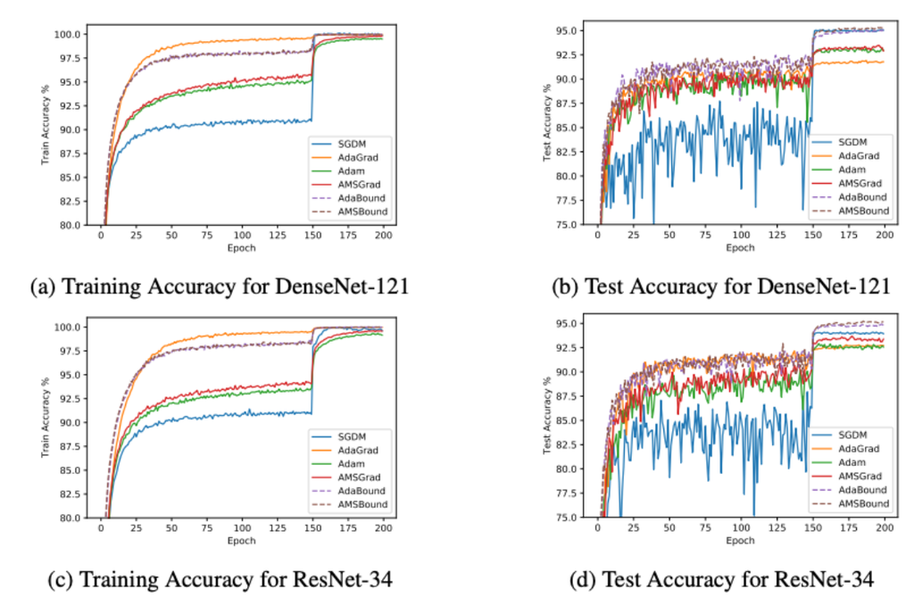

An Overview of most common optimizers used in ML.

### Different types of Optimizers

- **Gradient Descent**
- **Stochastic Gradient Descent (SGD)**
- **Mini-Batch Gradient Descent**
- **Stochastic Gradient Descent (SGD)with Momentum**
- **Adaptive Gradient Descent (AdaGrad)**
  - Gradient Descent with learning rate tuning
- **RMS-Prop (Root Mean Square Propagation)**
  - A special version of AdaGrad: Learning rate is an exponentially averaged of the gradients
  - Combination of AdaGrad & Momentum
- **AdaDelta**
- **Adam(Adaptive Moment Estimation)**
- **Nesterov Accelerated Gradient (NAG)**

## Gradient Descent

### Definition of Gradient:

A gradient measures how much the output of a function changes if you change the inputs a little bit." — Lex Fridman (MIT).

**Gradient/Slope,** $\boldsymbol{\nabla = \frac{Rise \,(\Delta Y)}{Run\,(\Delta X)}}$

- It measures the changes in the errors with respect to a small changes in the loss function.\
- It can easily undesrtand as the slope of a function.
- If the slope is steep the model approaches to the minima quickly, if the slope is too low the model stop learning and remains at a steady point.
- It is the partial derivative of the **Objective Function/Loss Function**

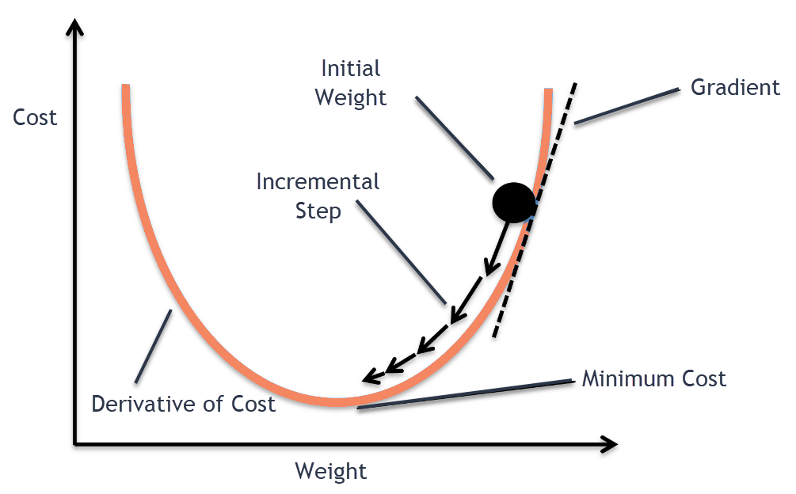

[**image source**](https://medium.com/@divakar_239/stochastic-vs-batch-gradient-descent-8820568eada1)

$$\boldsymbol{\theta = \theta - \eta. \overbrace{\nabla_{\theta}J(\theta;x,y)}^\text{Backpropagation}}$$

- $\boldsymbol{\theta}$ is a parameter (w,b, or activations). Here we only update a single parameter.
- $\boldsymbol{\eta}$ is the learning rate
- $\boldsymbol{\nabla}$ is Gradient of cost function $\boldsymbol{J}$
- $\boldsymbol{J}$ is the Pbjective function that we are going to optimize (commonly known as loss or cost function)

**Advantages:**

- Easy computation.
- Easy to implement.
- Easy to understand.

**Disadvantages:**

- May trap at local minima.
- Weights are changed after calculating the gradient on the whole dataset. So, if the dataset is too large then this may take years to converge to the minima.
- Requires large memory to calculate the gradient on the whole dataset.

**Learning rate:**

- Learning Rate is very important in Gardient Descent.
- If the learning rate is too high, it may step over the global minima.
- If the learning rate is too low, it may get stuck in the local minima.
- Learning rate is a hyper parameter, sometimes maybe optimized by Cross- Validations.

## [Last Reading Point](https://mlfromscratch.com/optimizers-explained/#/)